# Week7 Tutorial - Naive Bayes

13/3/2021

```r
# Import libraries
library(tidyverse)
library(DataExplorer)
library(VIM)
library(mice)
library(missForest)
library(caret)
library(psych)
library(reshape2)
library(ROCR)
library(naivebayes)
```

## 1. Dataset Description

### 1.1 General Information

#### Data Set: https://www.kaggle.com/sajidsaifi/prostate-cancer

#### Reference: https://www.kaggle.com/smogomes/prostate-cancer-prediction-model/notebook

- Feature number: 9
- Instance number: 100

### 1.2 Independent Variables

1. Radius (Continuous variable).
2. Texture (Continuous variable).
3. Perimeter (Continuous variable).
4. Area (Continuous variable).
5. Smoothness (Continuous variable).
6. Compactness (Continuous variable).
7. Symmetry (Continuous variable).
8. Fractal (Continuous variable).

### 1.3 Dependent Variables

1. Diagnosis result (Categorical variable): M (1), B (0).

```r
# Load data
df <- read.csv('Prostate_Cancer.csv', header = T)
```

## 2. Dataset Overview

```r
summary(df)
```

```
       id         diagnosis_result       radius         texture        perimeter
 Min.   :  1.00   Length:100         Min.   : 9.00   Min.   :11.00   Min.   : 52.00
 1st Qu.: 25.75   Class :character   1st Qu.:12.00   1st Qu.:14.00   1st Qu.: 82.50
 Median : 50.50   Mode  :character   Median :17.00   Median :17.50   Median : 94.00
 Mean   : 50.50                      Mean   :16.85   Mean   :18.23   Mean   : 96.78
 3rd Qu.: 75.25                      3rd Qu.:21.00   3rd Qu.:22.25   3rd Qu.:114.25
 Max.   :100.00                      Max.   :25.00   Max.   :27.00   Max.   :172.00
      area          smoothness      compactness        symmetry      fractal_dimension
 Min.   : 202.0   Min.   :0.0700   Min.   :0.0380   Min.   :0.1350   Min.   :0.05300
 1st Qu.: 476.8   1st Qu.:0.0935   1st Qu.:0.0805   1st Qu.:0.1720   1st Qu.:0.05900
 Median : 644.0   Median :0.1020   Median :0.1185   Median :0.1900   Median :0.06300
 Mean   : 702.9   Mean   :0.1027   Mean   :0.1267   Mean   :0.1932   Mean   :0.06469
 3rd Qu.: 917.0   3rd Qu.:0.1120   3rd Qu.:0.1570   3rd Qu.:0.2090   3rd Qu.:0.06900
 Max.   :1878.0   Max.   :0.1430   Max.   :0.3450   Max.   :0.3040   Max.   :0.09700
```

```r
# Dataset info
str(df)
```

```
'data.frame':   100 obs. of  10 variables:
 $ id               : int  1 2 3 4 5 6 7 8 9 10 ...
 $ diagnosis_result : chr  "M" "B" "M" "M" ...
 $ radius           : int  23 9 21 14 9 25 16 15 19 25 ...
 $ texture          : int  12 13 27 16 19 25 26 18 24 11 ...
 $ perimeter        : int  151 133 130 78 135 83 120 90 88 84 ...
 $ area             : int  954 1326 1203 386 1297 477 1040 578 520 476 ...
 $ smoothness       : num  0.143 0.143 0.125 0.07 0.141 0.128 0.095 0.119 0.127 0.119 ...
 $ compactness      : num  0.278 0.079 0.16 0.284 0.133 0.17 0.109 0.165 0.193 0.24 ...
 $ symmetry         : num  0.242 0.181 0.207 0.26 0.181 0.209 0.179 0.22 0.235 0.203 ...
 $ fractal_dimension: num  0.079 0.057 0.06 0.097 0.059 0.076 0.057 0.075 0.074 0.082 ...
```

## 4. Data Imputation

```r
# Prior to treating missing values any blanks in the data set must be converted to NA.
df <- mutate_all(df, na_if, "")
```

### 4.1 Plot Missing Values

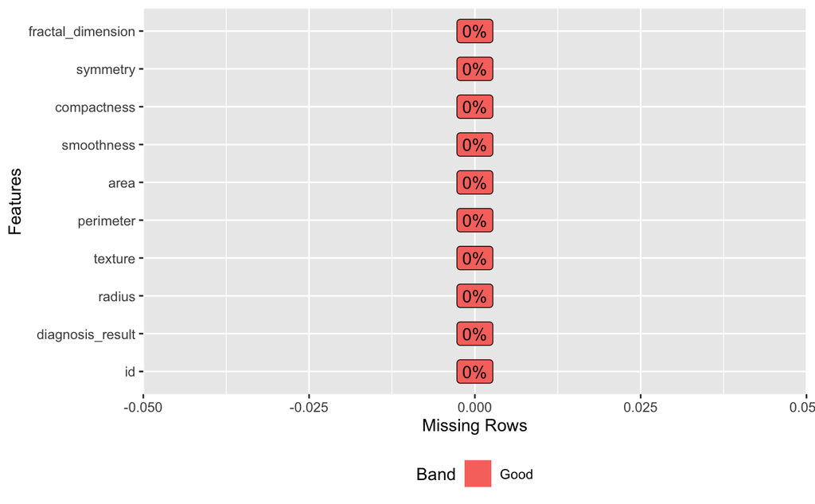

```r
# Viewing and counting missing data using DataExplorer package.
plot_missing(df)
```

Good News, there is no missing value now.

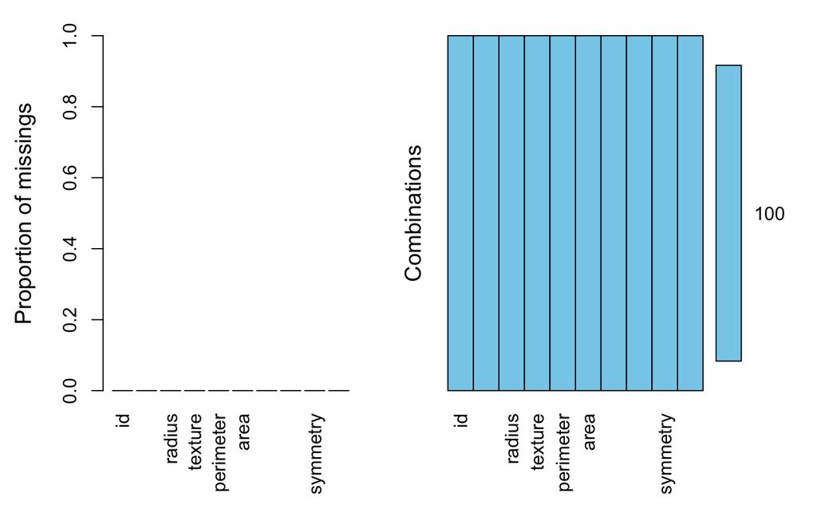

```r
# Using VIM library
vim_plot <- aggr(df, numbers=TRUE, prop = c(TRUE, FALSE))
```

As we can see, we have 100 records in total, and no missing value in this data set.

This function plots and calculates the amount of missing values in each variable and in certain combinations. On the right-hand chart, we can see the missing values’ distribution in a combination. Notice that left-hand chart uses proportions as Y-axis, while the right one uses real number because we set prop = c(TRUE, FALSE).

```
 /\     /\
{  `---'  }
{  O   O  }
==>  V <==  No need for mice. This data set is completely observed.
 \  \|/  /
  `-----'

    id diagnosis_result radius texture perimeter area smoothness compactness symmetry
100  1                1      1       1         1    1          1           1        1
     0                0      0       0         0    0          0           0        0
    fractal_dimension
100                 1 0
                    0 0
```

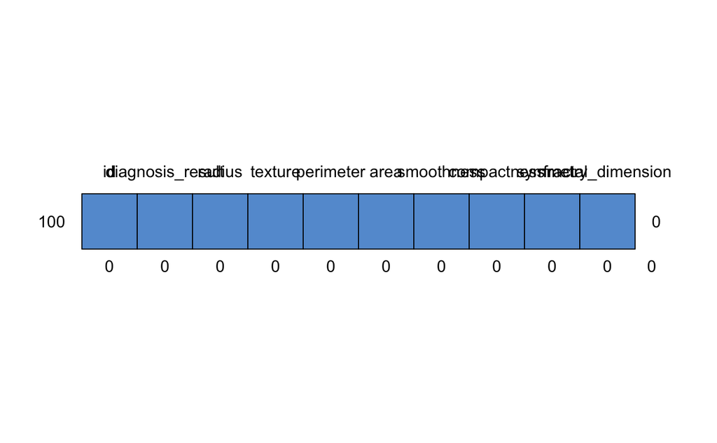

```r
# Using mice library
md.pattern(df)
```

This chart demonstrates the distribution of missing values. The values on the left side represent different groups of the data set. The values on the right side represent the total number of variables that contain missing value. The top line are names of different variables. The bottom line represents the number of missing values of each variable.

```r
# Overview of new data set
sum(is.na(df))
```

```
[1] 0
```

```r
head(df, 10)
```

|  | id | diagnosis_result | radius | texture | perimeter | area | smoothness | compactness | symmetry | fractal_dimension |
| --- | --- | --- | --- | --- | --- | --- | --- | --- | --- | --- |
| 1 | 1 | M | 23 | 12 | 151 | 954 | 0.143 | 0.278 | 0.242 | 0.079 |
| 2 | 2 | B | 9 | 13 | 133 | 1326 | 0.143 | 0.079 | 0.181 | 0.057 |
| 3 | 3 | M | 21 | 27 | 130 | 1203 | 0.125 | 0.160 | 0.207 | 0.060 |
| 4 | 4 | M | 14 | 16 | 78 | 386 | 0.070 | 0.284 | 0.260 | 0.097 |
| 5 | 5 | M | 9 | 19 | 135 | 1297 | 0.141 | 0.133 | 0.181 | 0.059 |
| 6 | 6 | B | 25 | 25 | 83 | 477 | 0.128 | 0.170 | 0.209 | 0.076 |
| 7 | 7 | M | 16 | 26 | 120 | 1040 | 0.095 | 0.109 | 0.179 | 0.057 |
| 8 | 8 | M | 15 | 18 | 90 | 578 | 0.119 | 0.165 | 0.220 | 0.075 |
| 9 | 9 | M | 19 | 24 | 88 | 520 | 0.127 | 0.193 | 0.235 | 0.074 |
| 10 | 10 | M | 25 | 11 | 84 | 476 | 0.119 | 0.240 | 0.203 | 0.082 |

## 5. Data Analyze

### 5.1 Distribution of diagnosis results

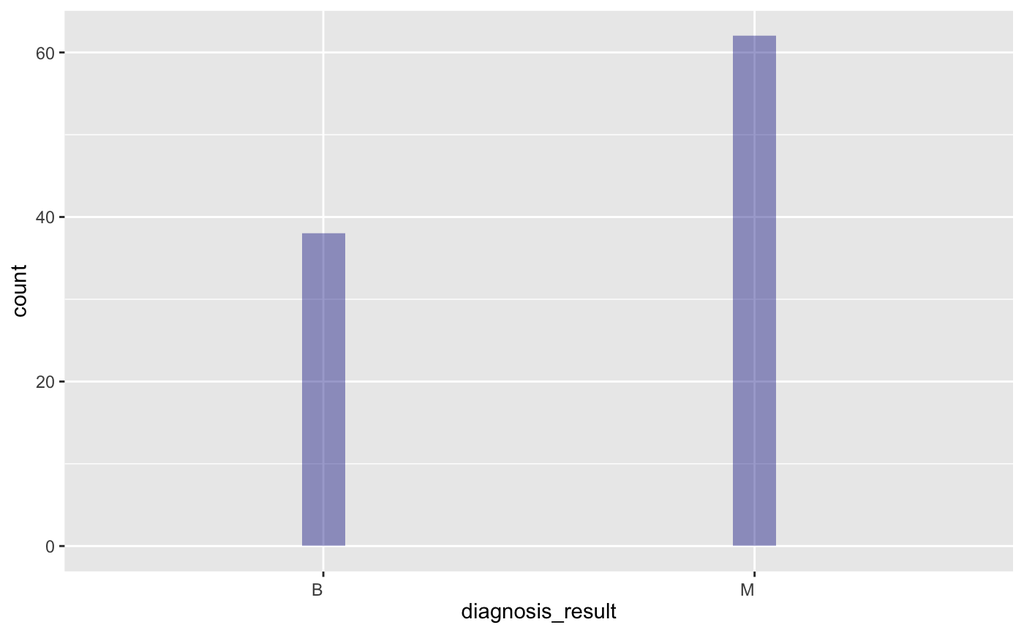

```r
ggplot(df, aes(x=diagnosis_result), color="darkblue") +
  geom_histogram(stat='count', aes(y = ..count..), width=.1, fill="darkblue", alpha=0.4) +
  theme(axis.text.x=element_text(angle=0, hjust=1, vjust=.5))
```

### 5.2 Distribution of the dependent variable.

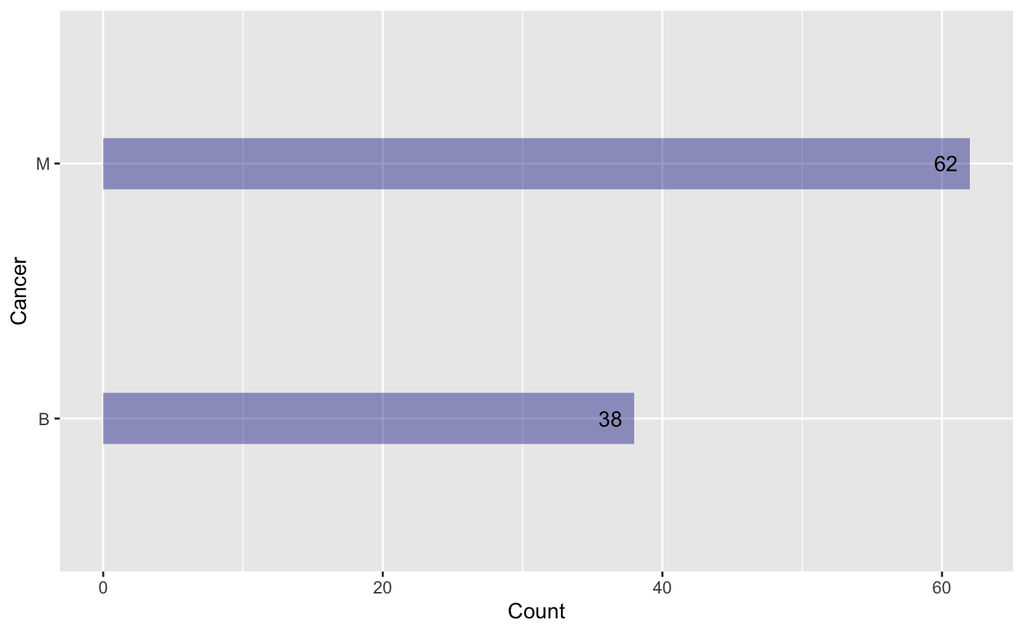

```r
ggplot(df, aes(y = diagnosis_result)) +
  geom_bar(width=.2, fill="darkblue", alpha=0.4) +
  xlab("Count") +
  ylab("Cancer") +
  geom_text(stat='count', aes(label=..count..), hjust=1.5, vjust=.5)
```

[figure not shown]

```r
barplot(table(df$diagnosis_result),
        xlab="Class (M = Benign, B = Malignant)", ylab="Count", col=c("darkblue","red"),
        legend = levels(df$diagnosis_result), beside=TRUE)
```

## 6. Feature Selection

### 6.1 Correlation matrix

```r
df.cor <- df %>%
      mutate(diagnosis_result = ifelse(diagnosis_result == "B", 0, 1))
str(df.cor)
```

```
'data.frame':   100 obs. of  10 variables:
 $ id               : int  1 2 3 4 5 6 7 8 9 10 ...
 $ diagnosis_result : num  1 0 1 1 1 0 1 1 1 1 ...
 $ radius           : int  23 9 21 14 9 25 16 15 19 25 ...
 $ texture          : int  12 13 27 16 19 25 26 18 24 11 ...
 $ perimeter        : int  151 133 130 78 135 83 120 90 88 84 ...
 $ area             : int  954 1326 1203 386 1297 477 1040 578 520 476 ...
 $ smoothness       : num  0.143 0.143 0.125 0.07 0.141 0.128 0.095 0.119 0.127 0.119 ...
 $ compactness      : num  0.278 0.079 0.16 0.284 0.133 0.17 0.109 0.165 0.193 0.24 ...
 $ symmetry         : num  0.242 0.181 0.207 0.26 0.181 0.209 0.179 0.22 0.235 0.203 ...
 $ fractal_dimension: num  0.079 0.057 0.06 0.097 0.059 0.076 0.057 0.075 0.074 0.082 ...
```

```r
cormat <- round(cor(select(df.cor, c("diagnosis_result", "radius", "texture", "perimeter", "area", "smoothness", "compactness", "symmetry", "fractal_dimension"))), 3)
# Merge data
melted_cormat = melt(cormat)
```

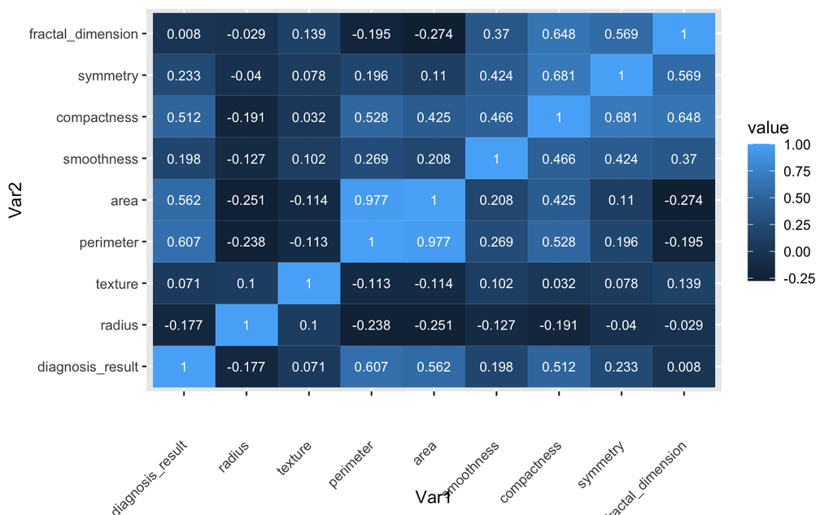

```r
ggplot(data=melted_cormat, aes(x=Var1, y=Var2, fill=value)) +
  geom_tile() +
  theme(axis.text.x=element_text(angle=45, hjust=1, vjust=.5)) +
  geom_text(aes(Var2, Var1, label = value),color='white', size=3)
```

```r
df.cor = subset(df.cor, select = -c(fractal_dimension, texture, perimeter) )
str(df.cor)
```

```
'data.frame':   100 obs. of  7 variables:
 $ id              : int  1 2 3 4 5 6 7 8 9 10 ...
 $ diagnosis_result: num  1 0 1 1 1 0 1 1 1 1 ...
 $ radius          : int  23 9 21 14 9 25 16 15 19 25 ...
 $ area            : int  954 1326 1203 386 1297 477 1040 578 520 476 ...
 $ smoothness      : num  0.143 0.143 0.125 0.07 0.141 0.128 0.095 0.119 0.127 0.119 ...
 $ compactness     : num  0.278 0.079 0.16 0.284 0.133 0.17 0.109 0.165 0.193 0.24 ...
 $ symmetry        : num  0.242 0.181 0.207 0.26 0.181 0.209 0.179 0.22 0.235 0.203 ...
```

### 6.2 Check Gaussianness

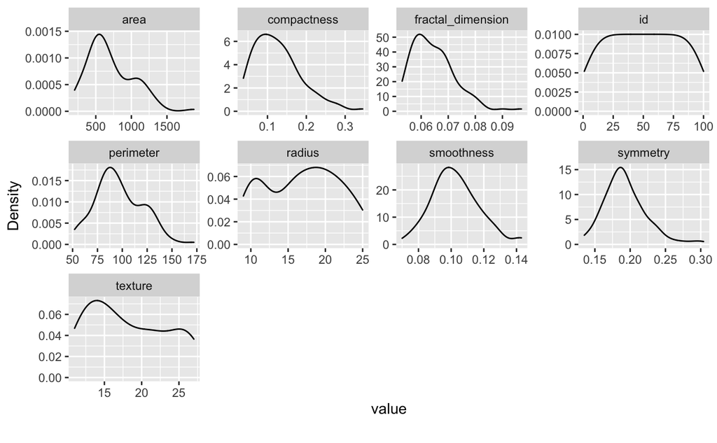

```r
# Check if the density plot os Gaussian
plot_density(df)
```

## 7. Data Normalization

```r
# Normalization
min_max_norm <- function(x) {
      (x - min(x)) / (max(x) - min(x))
}
df.norm = df.cor
df.norm[3:7] <- as.data.frame(lapply(df.cor[3:7], min_max_norm))
```

```r
sum(is.na(df))
```

```
[1] 0
```

```r
summary(df.norm)
```

```
       id         diagnosis_result     radius            area          smoothness
 Min.   :  1.00   Min.   :0.00     Min.   :0.0000   Min.   :0.0000   Min.   :0.0000
 1st Qu.: 25.75   1st Qu.:0.00     1st Qu.:0.1875   1st Qu.:0.1639   1st Qu.:0.3219
 Median : 50.50   Median :1.00     Median :0.5000   Median :0.2637   Median :0.4384
 Mean   : 50.50   Mean   :0.62     Mean   :0.4906   Mean   :0.2989   Mean   :0.4484
 3rd Qu.: 75.25   3rd Qu.:1.00     3rd Qu.:0.7500   3rd Qu.:0.4266   3rd Qu.:0.5753
 Max.   :100.00   Max.   :1.00     Max.   :1.0000   Max.   :1.0000   Max.   :1.0000
  compactness        symmetry
 Min.   :0.0000   Min.   :0.0000
 1st Qu.:0.1384   1st Qu.:0.2189
 Median :0.2622   Median :0.3254
 Mean   :0.2889   Mean   :0.3442
 3rd Qu.:0.3876   3rd Qu.:0.4379
 Max.   :1.0000   Max.   :1.0000
```

```r
# df.norm = df.norm %>% mutate(value = 1)  %>% spread(diagnosis_result, value,  fill = 0 )
# head(df.norm)
```

## 8. Data Set Partitioning

We use 80% of the data set for training, and the rest for testing.

```r
# 80% of the sample size
smp_size <- floor(0.80 * nrow(df))
set.seed(123)
train_ind <- sample(seq_len(nrow(df.norm)), size = smp_size)
train <- df.norm[train_ind, ]
test <- df.norm[-train_ind, ]
```

## 10. Naive Bayes

### 10.1 Check data distribution

```r
prop.table(table(df.norm$diagnosis_result))
```

```
   0    1
0.38 0.62
```

```r
prop.table(table(train$diagnosis_result))
```

```
     0      1
0.3875 0.6125
```

```r
prop.table(table(test$diagnosis_result))
```

```
   0    1
0.35 0.65
```

We can see that the training set and test set have similar label distributions as the original dataset.

### 10.2 Build classifier

```r
# Naive Bayes model
Naive_Bayes_basic = naive_bayes(x=train[ , -10],
                        y=as.factor(train$diagnosis_result), laplace=0 )
summary(Naive_Bayes_basic)
```

```
=========================================== Naive Bayes ===========================================

- Call: naive_bayes.default(x = train[, -10], y = as.factor(train$diagnosis_result),      laplace = 0)
- Laplace: 0
- Classes: 2
- Samples: 80
- Features: 7
- Conditional distributions:
    - Gaussian: 7
- Prior probabilities:
    - 0: 0.3875
    - 1: 0.6125

---------------------------------------------------------------------------------------------------
```

```r
# Lapace Naive Bayes
Naive_Bayes_laplace = naive_bayes(x=train[ , -17],
                                  y=as.factor(train$diagnosis_result), laplace = 1 )
summary(Naive_Bayes_laplace)
```

```
=========================================== Naive Bayes ===========================================

- Call: naive_bayes.default(x = train[, -17], y = as.factor(train$diagnosis_result),      laplace = 1)
- Laplace: 1
- Classes: 2
- Samples: 80
- Features: 7
- Conditional distributions:
    - Gaussian: 7
- Prior probabilities:
    - 0: 0.3875
    - 1: 0.6125

---------------------------------------------------------------------------------------------------
```

### 10.3 Training Process

```r
# y_train
pred_prob_training <- predict(Naive_Bayes_basic, type = 'class', train[ ,-10] )
# y_hat_train
# pred_class_training = ifelse(pred_prob_training > 0.5, 1, 0)
pred_class_training = ifelse(as.numeric(pred_prob_training) > 1.5, 1, 0)
# cbind(pred_prob_training, pred_class_training)
cm_training = table(train$diagnosis_result, pred_class_training)
# cm_training
```

```r
# y_train
pred_prob_laplace_training <- predict(Naive_Bayes_laplace, type = 'class', train[ ,-10] )
# y_hat_train
pred_class_laplace_training = ifelse(as.numeric(pred_prob_laplace_training) > 1.5, 1, 0)
cm_laplace_training = table(train$diagnosis_result, pred_class_laplace_training)
```

### 10.4 Confusion statistics using ‘kappa’ library

```r
confusionMatrix(cm_training)
```

```
Confusion Matrix and Statistics

   pred_class_training
     0  1
  0 31  0
  1  0 49

               Accuracy : 1
                 95% CI : (0.9549, 1)
    No Information Rate : 0.6125
    P-Value [Acc > NIR] : < 2.2e-16

                  Kappa : 1

 Mcnemar's Test P-Value : NA

            Sensitivity : 1.0000
            Specificity : 1.0000
         Pos Pred Value : 1.0000
         Neg Pred Value : 1.0000
             Prevalence : 0.3875
         Detection Rate : 0.3875
   Detection Prevalence : 0.3875
      Balanced Accuracy : 1.0000

       'Positive' Class : 0
```

```r
confusionMatrix(cm_laplace_training)
```

```
Confusion Matrix and Statistics

   pred_class_laplace_training
     0  1
  0 31  0
  1  0 49

               Accuracy : 1
                 95% CI : (0.9549, 1)
    No Information Rate : 0.6125
    P-Value [Acc > NIR] : < 2.2e-16

                  Kappa : 1

 Mcnemar's Test P-Value : NA

            Sensitivity : 1.0000
            Specificity : 1.0000
         Pos Pred Value : 1.0000
         Neg Pred Value : 1.0000
             Prevalence : 0.3875
         Detection Rate : 0.3875
   Detection Prevalence : 0.3875
      Balanced Accuracy : 1.0000

       'Positive' Class : 0
```

### 10.4 Training Evaluation (Accuracy)

```r
accuracy_training <- sum(diag(cm_training))/sum(cm_training)
accuracy_training
```

```
[1] 1
```

```r
accuracy_laplace_training <- sum(diag(cm_laplace_training))/sum(cm_laplace_training)
accuracy_laplace_training
```

```
[1] 1
```

### 10.5 Test Process

```r
# y_test
pred_prob_test <- predict(Naive_Bayes_basic, type = 'prob', test[ ,-10] )
pred_prob_test
```

```
                 0            1
 [1,] 5.819624e-12 1.000000e+00
 [2,] 5.358639e-01 4.641361e-01
 [3,] 4.423722e-08 1.000000e+00
 [4,] 4.731210e-06 9.999953e-01
 [5,] 3.297347e-11 1.000000e+00
 [6,] 1.098223e-08 1.000000e+00
 [7,] 9.331812e-08 9.999999e-01
 [8,] 3.484271e-06 9.999965e-01
 [9,] 1.657574e-06 9.999983e-01
[10,] 5.798795e-06 9.999942e-01
[11,] 3.297094e-06 9.999967e-01
[12,] 9.999999e-01 7.460474e-08
[13,] 1.025281e-05 9.999897e-01
[14,] 9.999999e-01 1.075449e-07
[15,] 1.000000e+00 4.585684e-08
[16,] 1.000000e+00 2.731979e-08
[17,] 1.694337e-05 9.999831e-01
[18,] 9.999996e-01 3.808337e-07
[19,] 4.957065e-08 1.000000e+00
[20,] 1.000000e+00 2.111145e-08
```

```r
# y_hat_test
pred_class_test = ifelse(pred_prob_test > 0.5, 1, 0)
# pred_class_test

test_enc = test %>% mutate(value = 1)  %>% spread(diagnosis_result, value,  fill = 0 )

t = cbind(test_enc$'0', test_enc$'1')

cm_test = table(t, pred_class_test)
cm_test
```

```
   pred_class_test
t    0  1
  0 20  0
  1  0 20
```

### 10.6 Testing Accuracy

```r
accuracy_test <- sum(diag(cm_test))/sum(cm_test)
accuracy_test
```

```
[1] 1
```

## 11. AUC & ROC Analysis

```r
# To draw ROC we need to predict the prob values.
pred = prediction(pred_prob_test, t)
perf = performance(pred, "tpr", "fpr")
pred
```

```
A prediction instance
  with 2 cross validation runs (equal lengths)
```

```r
perf
```

```
A performance instance
  'False positive rate' vs. 'True positive rate' (alpha: 'Cutoff')
  for 2 cross validation runs
```

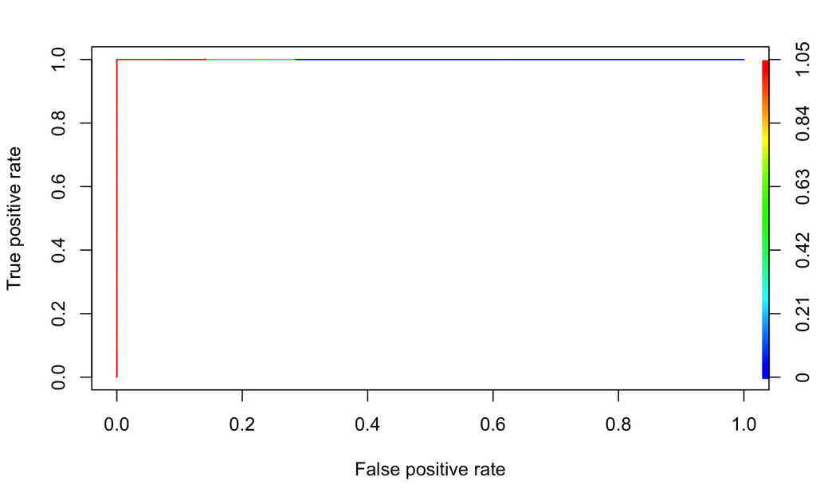

```r
plot(perf, colorize = T)
```

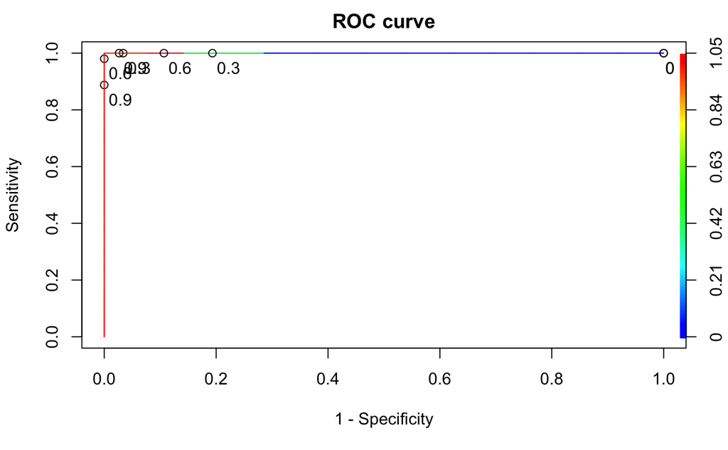

```r
plot(perf, colorize=T,
     main = "ROC curve",
     ylab = "Sensitivity",
     xlab = "1 - Specificity",
     print.cutoffs.at=seq(0,1,0.3),
     text.adj= c(-0.2,1.7))
```

```r
# Area Under Curve
auc <- as.numeric(performance(pred, "auc")@y.values)
auc <-  round(auc, 3)
auc
```

```
[1] 1 1
```

```r
cat("Last Block!")
```

```
Last Block!
```